# Week 9 - Tree-Based Methods

### Dr. David Elliott

1.1. Introduction

1.2. Dataset Example: Penguins

1.3. General Decision Tree Algorithm

1.4. Specific Decision Tree Algorithms

# 1.1. Introduction

*Tree-based* methods *stratify* or *segment* the predictor space into a number of simple regions<sup>1</sup>. As the spliting rules to make these decision regions can be summerised in a tree structure, these approaches are called *decision trees*.

A decision tree breaks data down by asking a series of questions in order to categorise samples into the same class.

We will be looking at how we can use them alone as well as in ensembles.

## **Terminology**<sup>5</sup>

**Root node:** no incoming edge, zero, or more outgoing edges.

**Internal node:** one incoming edge, two (or more) outgoing edges.

**Leaf node:** each leaf node is assigned a class label if nodes are pure; otherwise, the class label is determined by majority vote.

**Parent and child nodes:** If a node is split, we refer to that given node as the parent node, and the resulting nodes are called child nodes.

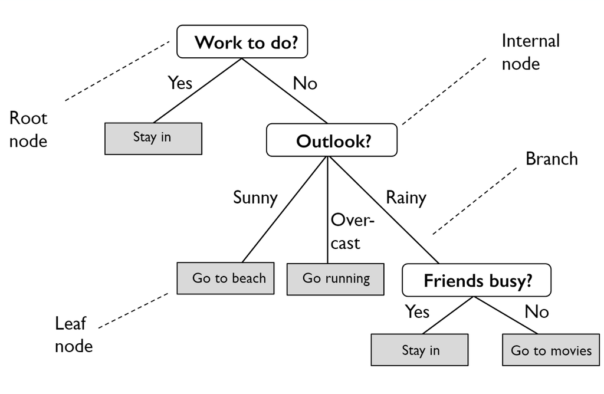

# 1.2. Dataset Example: Penguins

The *"palmer penguins"* dataset<sup>2</sup> contains data for 344 penguins from 3 different species and from 3 islands in the Palmer Archipelago, Antarctica.

|  | species | island | bill_length_mm | bill_depth_mm | flipper_length_mm | body_mass_g | sex |
| --- | --- | --- | --- | --- | --- | --- | --- |
| 0 | Adelie | Torgersen | 39.1 | 18.7 | 181.0 | 3750.0 | Male |
| 1 | Adelie | Torgersen | 39.5 | 17.4 | 186.0 | 3800.0 | Female |
| 2 | Adelie | Torgersen | 40.3 | 18.0 | 195.0 | 3250.0 | Female |
| 3 | Adelie | Torgersen | NaN | NaN | NaN | NaN | NaN |
| 4 | Adelie | Torgersen | 36.7 | 19.3 | 193.0 | 3450.0 | Female |

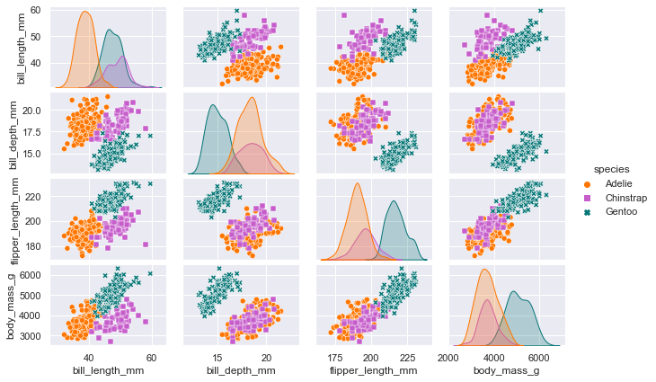

# 1.3. General Decision Tree Algorithm

An algorithm starts at a tree root and then splits the data based on the features that give the best split based on a splitting criterion.

Generally this splitting procedure occours until<sup>3,4</sup>...

- ...all the samples within a given node all belong to the same class,
- ...the maximum depth of the tree is reached,
- ...a split cannot be found that improves the model.

Below is an example of a very shallow decision tree where we have set `max_depth = 1`.

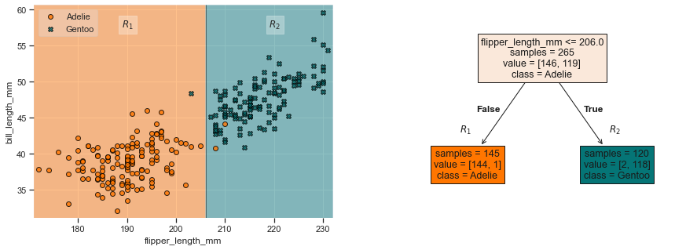

We can make the tree *"deeper"*, and therefore more complex, by setting the `max_depth = 3`.

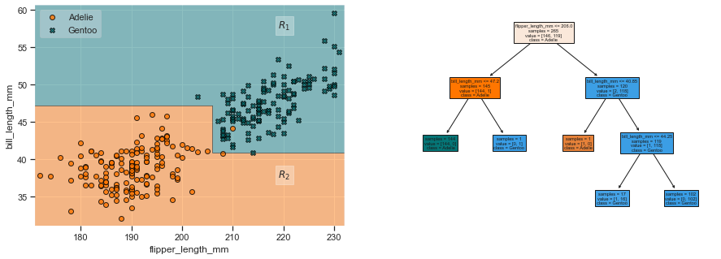

We could also use more than 2 features as seen below.

[figure not shown]

We could also also easily extend this to have more than a 2 (binary) class labels.

[figure not shown]

In a general sense this approach is pretty simple, however there are a number of design choices and considerations we have to make including<sup>5</sup>:

- How do we decide which features to select for splitting a parent node into child nodes?
- How do we decide where to split features?
- When do we stop growing a tree?
- How do we make predictions if no attributes exist to perfectly separate non-pure nodes further?

# 1.4. Specific Decision Tree Algorithms

Most decision tree algorithms address the following implimentation choices differently<sup>5</sup>:

- **Splitting Criterion:** Information gain, statistical tests, objective function, etc.
- **Number of Splits:** Binary or multi-way
- **Variables:** Discrete vs. Continuous
- **Pruning**: Pre- vs. Post-pruning

There are a number of decision tree algorithms, prominant ones include:

- Iterative Dichotomizer 3 (ID3)
- C4.5
- **CART**

## CART

Scikit-Learn uses an optimised version of the Classification And Regression Tree (CART) algorithm.

- **Splitting Criterion:** Information gain
- **Number of Splits:** Binary
- **Independent Variables (Features):** Continuous
- **Dependent variable**: Continuous or Categorical
- **Pruning**: Pre- & Post-pruning

## Information Gain<sup>4</sup>

An algorithm starts at a tree root and then splits the data based on the feature, $f$, that gives the largest information gain, $IG$.

To split using information gain relies on calculating the difference between an impurity measure of a parent node, $D_p$, and the impurities of its child nodes, $D_j$; information gain being high when the sum of the impurity of the child nodes is low.

We can maximise the information gain at each split using,

$$IG(D_p,f) = I(D_p)-\sum^m_{j=1}\frac{N_j}{N_p}I(D_j),$$

where $I$ is out impurity measure, $N_p$ is the total number of samples at the parent node, and $N_j$ is the number of samples in the $j$th child node.

Some algorithms, such as Scikit-learn's implimentation of CART, reduce the potential search space by implimenting binary trees:

$$IG(D_p,f) = I(D_p) - \frac{N_\text{left}}{N_p}I(D_\text{left})-\frac{N_\text{right}}{N_p}I(D_\text{right}).$$

Three impurity measures that are commonly used in binary decision trees are the *classification error* ($I_E$), *gini impurity* ($I_G$), and *entropy* ($I_H$)<sup>4</sup>.

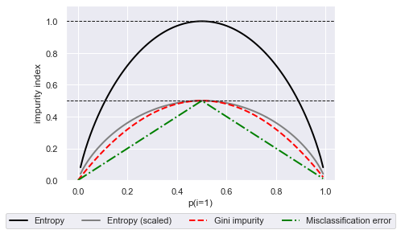

### Classification Error<sup>4</sup>

$$I_E = 1 - \max\left\{p(i|t)\right\}$$

Here $p(i|t)$ is the proportion of the samples that belong to the $i$th class $c$, for node $t$.

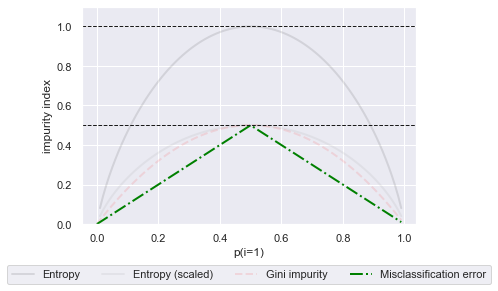

### Entropy Impurity<sup>4</sup>

For all non-empty classes ($p(i|t) \neq 0$), entropy is given by

$$I_H=-\sum^c_{i=1}p(i|t)\log_2p(i|t).$$

The entropy is therefore 0 if all samples at the node belong to the same class and maximal if we have a uniform class distribution.

For example in binary classification ($c=2$):

- $I_H=0 \text{ if } p(i=1|t)=1 \text{ or } p(i=0|t)=0$
- $I_H=1 \text{ if } p(i=1|t)=0.5 \text{ or } p(i=0|t)=0.5$

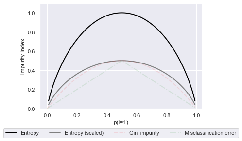

### Gini Impurity<sup>4</sup>

Gini Impurity is an alternative measurement, which minimises the probabilty of misclassification,

$$ \begin{align} I_G(t) &= \sum^c_{i=1}p(i|t)(1-p(i|t)) \\ &= 1-\sum^c_{i=1}p(i|t)^2. \end{align} $$

This measure is also maximal when classes are perfectly mixed (e.g. $c=2$):

$$ \begin{align} I_G(t) &= 1 - \sum^c_{i=1}0.5^2 = 0.5. \end{align} $$

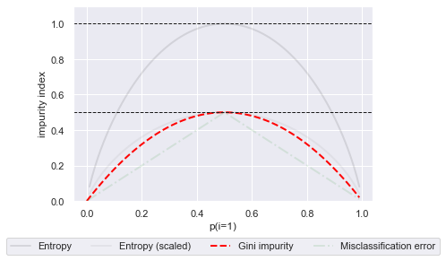

### Why not Classification Error

*Classification Error* is rarely used for infomration gain in practice (its not even an option in `scikit-learn`).

This is because it can mean that tree growth gets stuck and error doesnt improve, this is not the case for a concave function such as entropy or gini.

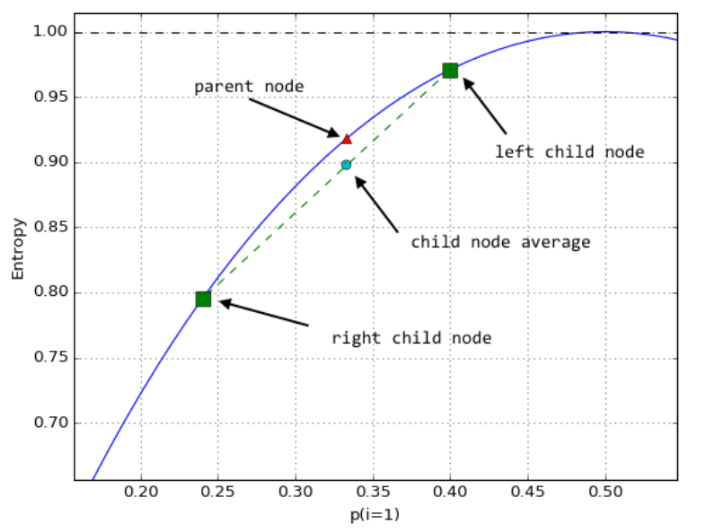

## Pruning

**Question:** When do we stop growing a tree?

*Occam’s razor*: Favor a simpler hypothesis, because a simpler hypothesis that fits the data equally well is more likely or plausible than a complex one<sup>5</sup>.

To minimize overfitting, we can either set limits on the trees before building them (pre-pruning), or reduce the tree by removing branches that do not significantly contribute (post-pruning).

`load_breast_cancer`

```
<class 'pandas.core.frame.DataFrame'>
RangeIndex: 569 entries, 0 to 568
Data columns (total 30 columns):
 #   Column                   Non-Null Count  Dtype
---  ------                   --------------  -----
 0   mean radius              569 non-null    float64
 1   mean texture             569 non-null    float64
 2   mean perimeter           569 non-null    float64
 3   mean area                569 non-null    float64
 4   mean smoothness          569 non-null    float64
 5   mean compactness         569 non-null    float64
 6   mean concavity           569 non-null    float64
 7   mean concave points      569 non-null    float64
 8   mean symmetry            569 non-null    float64
 9   mean fractal dimension   569 non-null    float64
```

[output cut: 22 more lines]

```
None
```

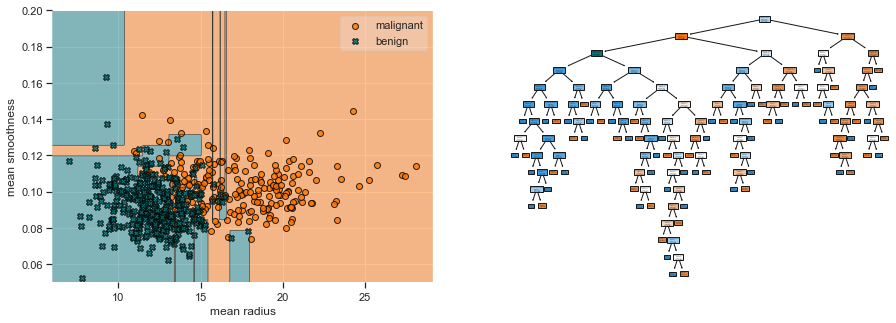

### Pre-Pruning

An a priori limit on nodes, or tree depth, is often set to avoid overfitting due to a deep tree<sup>4,5</sup>.

```
Using GridSearch, the best maximum tree depth was found to be: 1
```

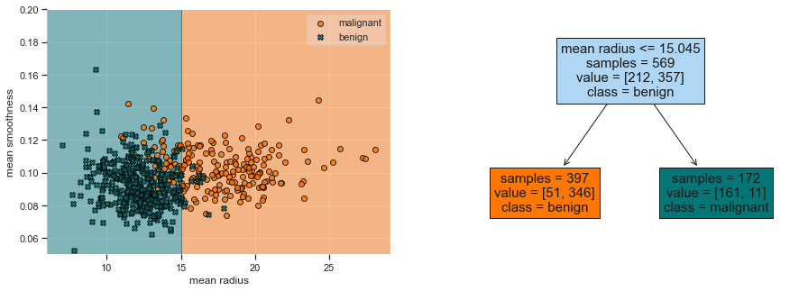

We could also set a minimum number of data points for each node<sup>5</sup>.

```
Using GridSearch, the best minimum samples per leaf was found to be: 13
```

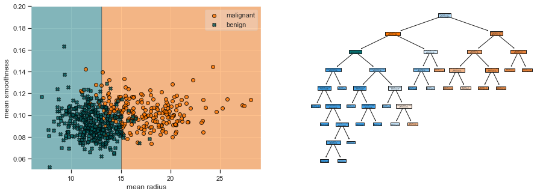

### Post-Pruning

In general, post-pruning consists of going back through the tree once it has been created and removing branches that do not significantly contribute to the error reduction and replacing them with leaf nodes<sup>6</sup>

Two common approaches are *reduced-error pruning* and *cost-complexity pruning*

- **Reduced-error pruning**<sup>5</sup>
  - Greedily remove nodes based on validation set performance
  - Generally improves performance but can be problematic for limited data set sizes.
- **Cost-complexity pruning**<sup>5</sup>
  - Recursively finds the node with the “weakest link”.
  - Nodes are characterized by $\alpha \geq 0$, and nodes with the smallest effective $\alpha$ are pruned first<sup>7</sup>.
  - The trees are then defined as $I + \alpha|N|$, where $I$ is an impurity measure, such as the total misclassification rate of the terminal nodes, $\alpha$ is a tuning parameter, and $|N|$ is the total number of nodes<sup>5</sup>.

#### Cost-complexity pruning<sup>7</sup>

Using `Scikit-learn`, we can recursively fit a complex tree with no prior pruning and have a look at the effective alphas and the corresponding total leaf impurities at each step of the pruning process.

As alpha increases, more of the tree is pruned, thus creating a decision tree that generalizes better.

We can select the alpha that reduces the distance between the train and validation scores.

```
Number of nodes in the last tree is: 1 with ccp_alpha: 0.25163892346166594
```

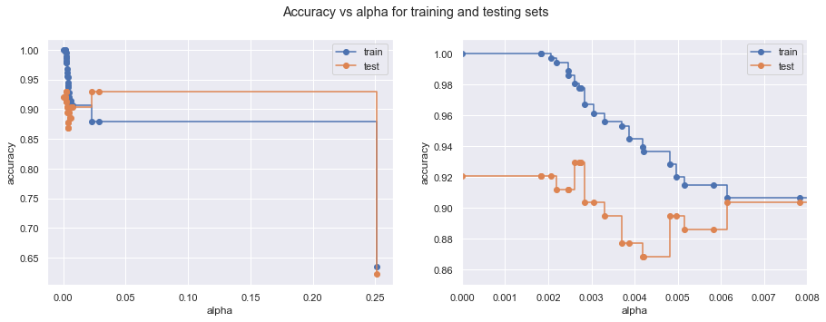

Then we can train a decision tree using the chosen effective alpha.

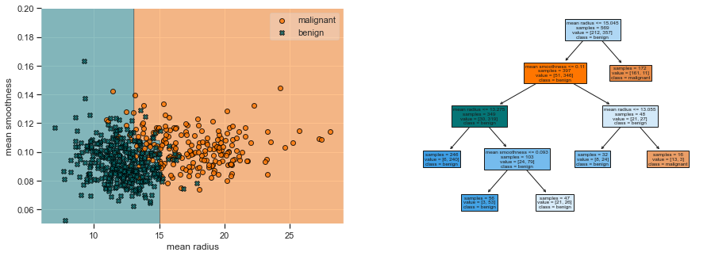

### Other Algorithms

**ID3 - Iterative Dichotomizer 3**<sup>8</sup>

- **Splitting Criterion:** Maximises Information Gain/ Minimises Entropy
- **Number of Splits:** Multiway
- **Variables:** Discrete binary and multi-category features
- **Pruning**: None

**C4.5**<sup>9</sup>

- **Splitting Criterion:** Maximises Information Gain/ Minimises Entropy
- **Number of Splits:** Multiway
- **Variables:** Discrete & Continuous (expensive)
- **Pruning**: Post-Pruning
- can handle missing data
- C5.0 is the latest release version under a proprietary license

# Associated Exercises

# References

1. James, Gareth, Daniela Witten, Trevor Hastie, and Robert Tibshirani. An introduction to statistical learning. Vol. 112. New York: springer, 2013.
2. Gorman KB, Williams TD, Fraser WR (2014). Ecological sexual dimorphism and environmental variability within a community of Antarctic penguins (genus Pygoscelis). PLoS ONE 9(3):e90081. https://doi.org/10.1371/journal.pone.0090081
3. Géron, A. (2017). Hands-on machine learning with Scikit-Learn and TensorFlow: concepts, tools, and techniques to build intelligent systems. " O'Reilly Media, Inc.".
4. Raschka, Sebastian, and Vahid Mirjalili. Python Machine Learning, 2nd Ed. Packt Publishing, 2017.
5. https://github.com/rasbt/stat479-machine-learning-fs19/blob/master/06_trees/06-trees__notes.pdf
6. Burkov, A. (2019). The hundred-page machine learning book (Vol. 1). Canada: Andriy Burkov.
7. https://scikit-learn.org/stable/auto_examples/tree/plot_cost_complexity_pruning.html#:~:text=Cost%20complexity%20pruning%20provides%20another,the%20number%20of%20nodes%20pruned.
8. Quinlan, J. R. (1986). Induction of decision trees. Machine learning, 1 (1), 81-106
9. Quinlan, J. R. (1993). C4. 5: Programming for machine learning. Morgan Kauffmann, 38, 48.